# Model validation plots

Eric R. Scott

01 September, 2021

# Survival

## Forest Fragments

### Diagnostics

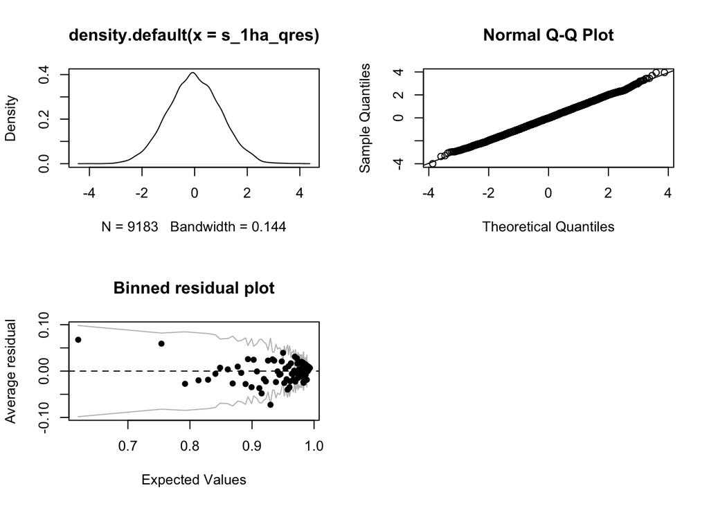

```r
s_1ha_qres <- qresid(s_1ha)
par(mfrow = c(2,2))
#histogram
plot(density(s_1ha_qres))
#QQ plot
qqnorm(s_1ha_qres); qqline(s_1ha_qres)
#Fitted vs. residuals--binned residuals plot
binnedplot(fitted(s_1ha), residuals(s_1ha, type = "response"))
```

### Basis dimensions

```r
k.check(s_1ha)
```

```
##                   k'          edf   k-index p-value
## s(log_size_prev)   9 2.842177e+00 0.9584417   0.935
## s(spei_history,L) 90 1.077927e+01        NA      NA
## s(plot)            4 1.627924e-04        NA      NA
```

`k` is adequate for `log_size_prev`. Unfortunately `k.check()` doesn’t work for data with matrices, so I’ll use an alternative approach detailed in `?mgcv::choose.k` for the crossbasis smooth. Briefly, it involves looking for pattern in residuals by extracting residuals and fitting a GAM to them with the smooth of interest with an increased value for `k`. If there is no unexplained pattern in residuals, that smooth should have an edf near zero.

```r
# Function sourced from R/utils.R
check_res_edf(s_1ha)
```

```
## # A tibble: 1 x 2
##   smooth               edf
##   <chr>              <dbl>
## 1 te(spei_history,L)     0
```

Adequate k for crossbasis.

## Continuous Forest

### Diagnostics

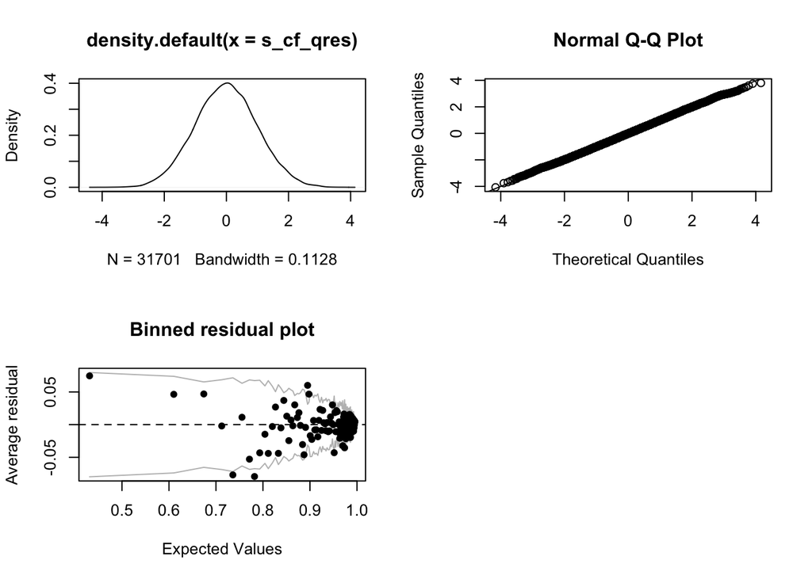

```r
s_cf_qres <- qresid(s_cf)
par(mfrow = c(2,2))
#histogram
plot(density(s_cf_qres))
#QQ plot
qqnorm(s_cf_qres); qqline(s_cf_qres)
#Fitted vs. residuals--binned residuals plot
binnedplot(fitted(s_cf), residuals(s_cf, type = "response"))
```

### Basis dimensions

```r
k.check(s_cf)
```

```
##                    k'       edf   k-index p-value
## s(log_size_prev)    9  3.457925 0.9099995  0.1925
## s(spei_history,L) 210 12.795976        NA      NA
## s(plot)             6  4.336851        NA      NA
```

Adequate knots for `log_size_prev`

```r
check_res_edf(s_cf)
```

```
## # A tibble: 1 x 2
##   smooth               edf
##   <chr>              <dbl>
## 1 te(spei_history,L)   1.1
```

Adequate knots for crossbasis smooth.

## Effect of sample size

Here I use a random sub-sample to check that differences between continuous forest and fragments are not purely due to sample size differences, particularly differences in the complexity and shape of the crossbasis smooth.

```r
summary(s_1ha)$edf[2]
```

```
## [1] 10.77927
```

```r
summary(s_cf)$edf[2]
```

```
## [1] 12.79598
```

```r
summary(s_cf_sub)$edf[2]
```

```
## [1] 4.037507
```

The crossbasis is smoother, but shows a similar pattern.

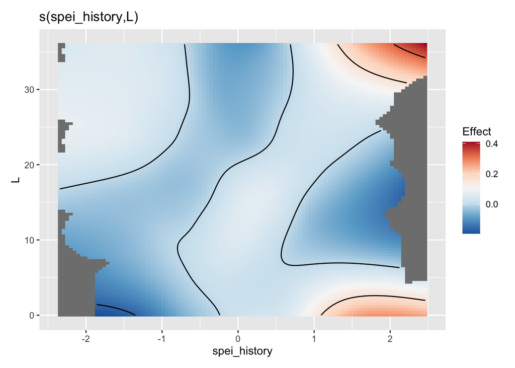

```r
draw(s_cf, select = "s(spei_history,L)", n_contour = 5)
```

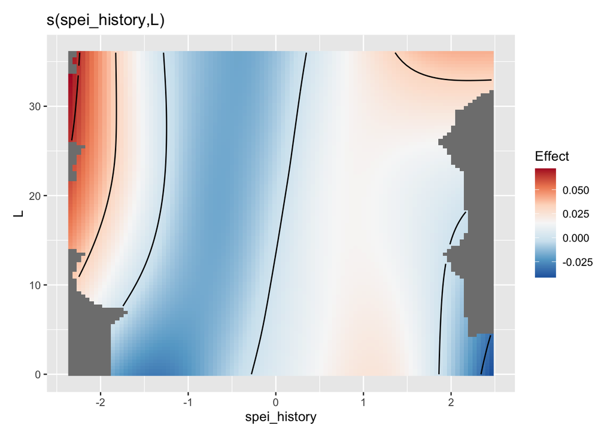

```r
draw(s_cf_sub, select = "s(spei_history,L)", n_contour = 5)
```

# Growth

## Fragments

### Diagnostics

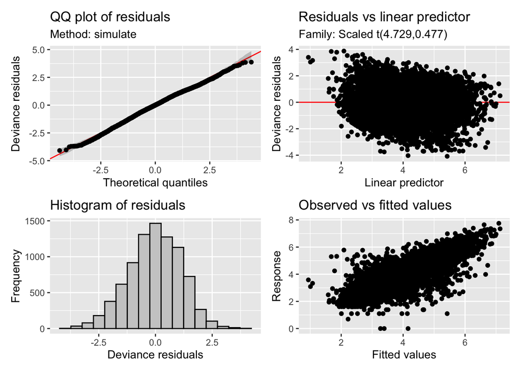

```r
appraise(g_1ha)
```

### Basis dimensions

```r
k.check(g_1ha)
```

```
##                   k'       edf   k-index p-value
## s(log_size_prev)   9  4.193967 0.9818494  0.1025
## s(spei_history,L) 60 18.181554        NA      NA
## s(plot)            4  2.826248        NA      NA
```

Adequate k for `log_size_prev`.

```r
check_res_edf(g_1ha)
```

```
## # A tibble: 1 x 2
##   smooth               edf
##   <chr>              <dbl>
## 1 te(spei_history,L)     0
```

Adequate k for crossbasis.

## Continuous Forest

### Diagnostics

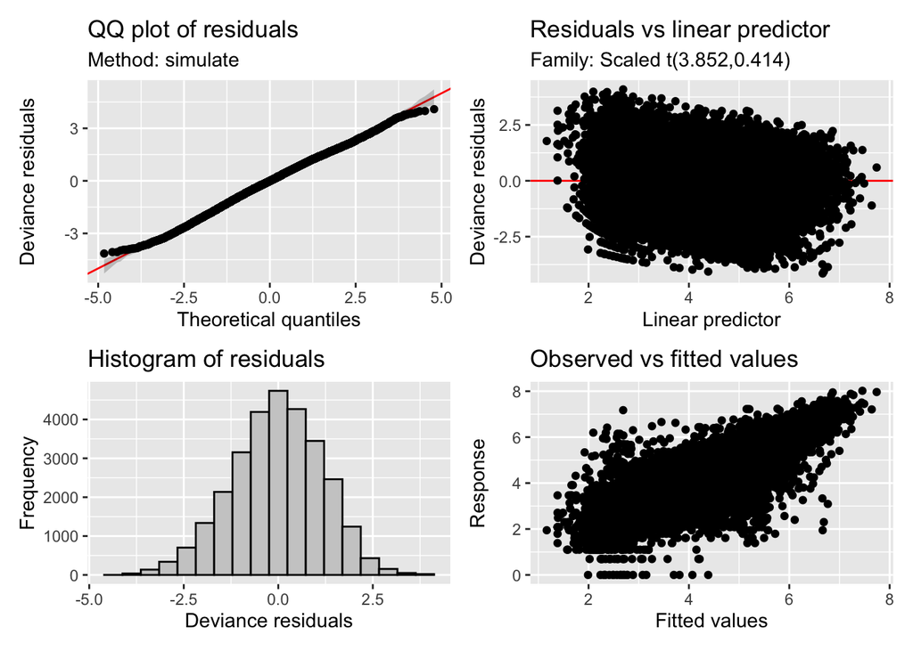

```r
gratia::appraise(g_cf)
```

### Basis dimensions

```r
k.check(g_cf)
```

```
##                   k'       edf  k-index p-value
## s(log_size_prev)  24  9.386988 0.967252   0.015
## s(spei_history,L) 60 15.144505       NA      NA
## s(plot)            6  4.080451       NA      NA
```

Adequate k for `log_size_prev`

```r
check_res_edf(g_cf)
```

```
## # A tibble: 1 x 2
##   smooth               edf
##   <chr>              <dbl>
## 1 te(spei_history,L)     0
```

Adequate k for crossbasis smooth.

## Effect of sample size

To check that differences are not purely due to sample size differences, particularly that lower edf in continuous forests is due to higher sample size.

```r
summary(g_1ha)$edf[2]
```

```
## [1] 18.18155
```

```r
summary(g_cf)$edf[2]
```

```
## [1] 15.1445
```

```r
summary(g_cf_sub)$edf[2]
```

```
## [1] 14.60322
```

edf is similar for the sub-sample

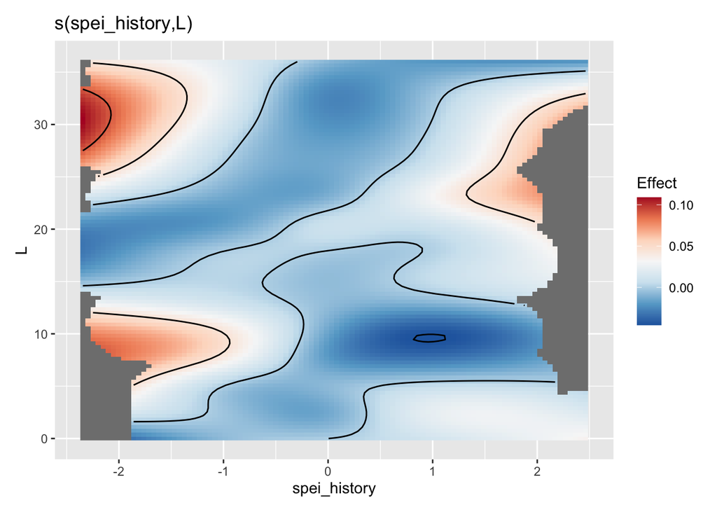

```r
draw(g_cf, select = "s(spei_history,L)", n_contour = 5)
```

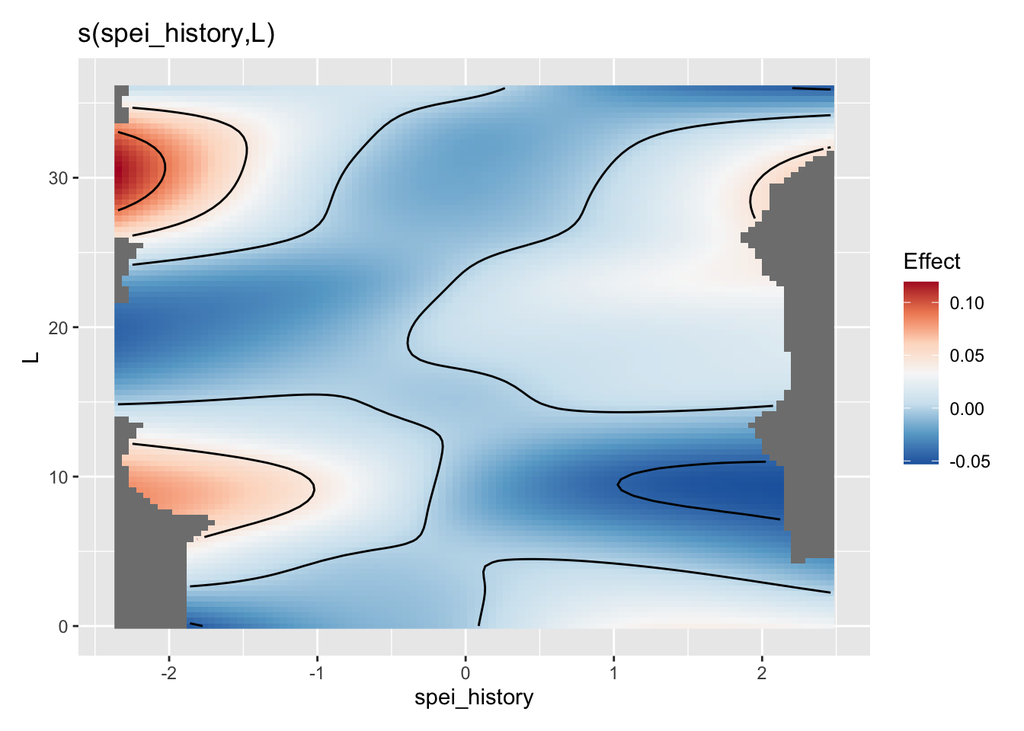

```r
draw(g_cf_sub, select = "s(spei_history,L)", n_contour = 5)
```

The shape of the smooth is also similar.

# Flowering

## Fragments

### Diagnostics

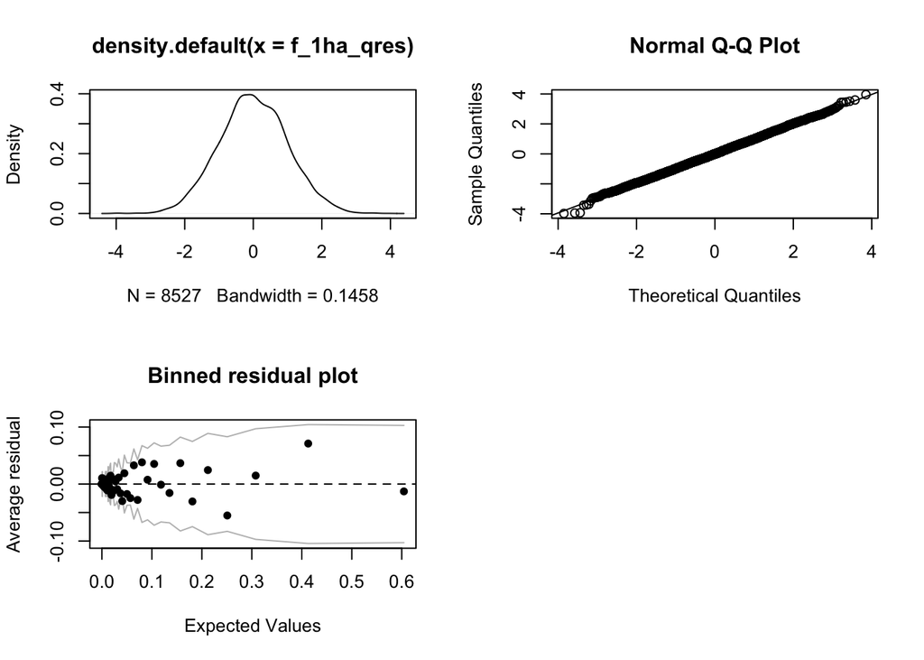

```r
f_1ha_qres <- qresid(f_1ha)
par(mfrow = c(2,2))
#histogram
plot(density(f_1ha_qres))
#QQ plot
qqnorm(f_1ha_qres); qqline(f_1ha_qres)
#Fitted vs. residuals--binned residuals plot
binnedplot(fitted(f_1ha), residuals(f_1ha, type = "response"))
```

### Basis dimensions

```r
k.check(f_1ha)
```

```
##                    k'       edf  k-index p-value
## s(log_size_prev)    9  3.400302 0.998162    0.96
## s(spei_history,L) 162 14.127281       NA      NA
## s(plot)             4  2.514545       NA      NA
```

Adequate k for `log_size_prev`

```r
# looking for near zero edf
check_res_edf(f_1ha)
```

```
## # A tibble: 1 x 2
##   smooth               edf
##   <chr>              <dbl>
## 1 te(spei_history,L)     0
```

Adequate k for crossbasis smooth.

## Continuous Forest

### Diagnostics

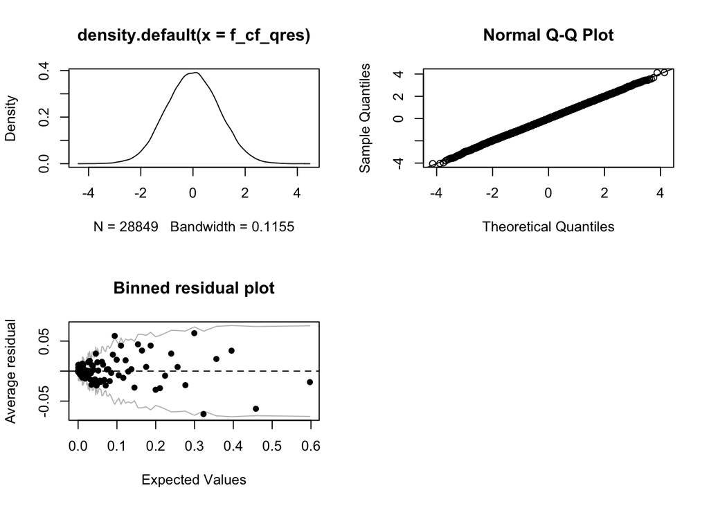

```r
f_cf_qres <- qresid(f_cf)
par(mfrow = c(2,2))
#histogram
plot(density(f_cf_qres))
#QQ plot
qqnorm(f_cf_qres); qqline(f_cf_qres)
#Fitted vs. residuals--binned residuals plot
binnedplot(fitted(f_cf), residuals(f_cf, type = "response"))
```

### Basis dimensions

```r
k.check(f_cf)
```

```
##                    k'       edf   k-index p-value
## s(log_size_prev)    9  5.795259 0.9746386    0.71
## s(spei_history,L) 210 11.451012        NA      NA
## s(plot)             6  3.950101        NA      NA
```

Adequate k for `log_size_prev`

```r
# looking for near zero edf
check_res_edf(f_cf)
```

```
## # A tibble: 1 x 2
##   smooth               edf
##   <chr>              <dbl>
## 1 te(spei_history,L)   1.2
```

Adequate k for crossbasis.

## Effect of sample size

To check that differences are not purely due to sample size differences, particularly that lower edf in continuous forests is due to higher sample size.

```r
summary(f_1ha)$edf[2]
```

```
## [1] 14.12728
```

```r
summary(f_cf)$edf[2]
```

```
## [1] 11.45101
```

```r
summary(f_cf_sub)$edf[2]
```

```
## [1] 6.865072
```

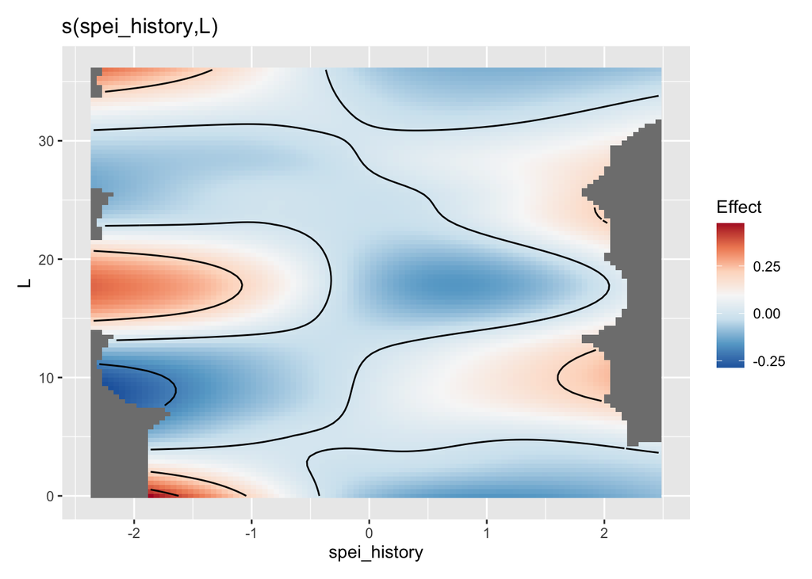

```r
draw(f_cf, select = "s(spei_history,L)", n_contour = 5)
```

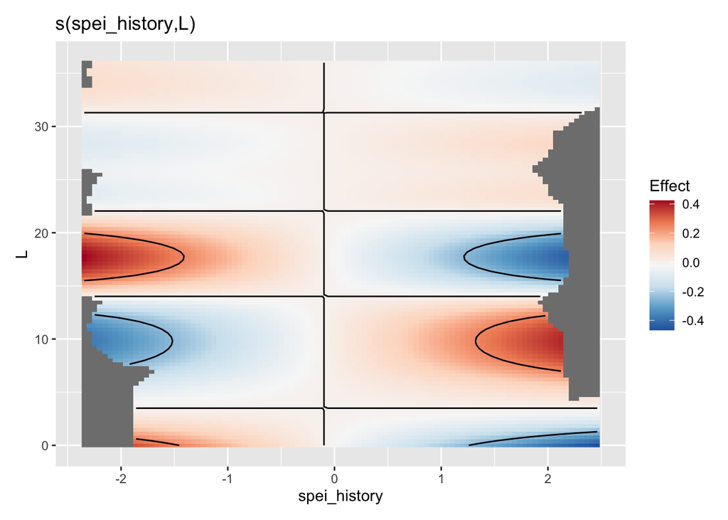

```r
draw(f_cf_sub, select = "s(spei_history,L)", n_contour = 5)
```

Similar, but essentially linear in SPEI dimension.

# Reproducibility

**Reproducibility receipt**

```r
## datetime
Sys.time()
```

```
## [1] "2021-09-01 16:05:09 EDT"
```

```r
## repository
if(requireNamespace('git2r', quietly = TRUE)) {
  git2r::repository()
} else {
  c(
    system2("git", args = c("log", "--name-status", "-1"), stdout = TRUE),
    system2("git", args = c("remote", "-v"), stdout = TRUE)
  )
}
```

```
## Local:    revisions /Users/scottericr/Documents/HeliconiaDemography
## Remote:   revisions @ origin (https://github.com/BrunaLab/HeliconiaDemography.git)
## Head:     [19ffd10] 2021-09-01: add raw data plot supplement. closes #79
```